# Linear Model

Jesse

2019年12月9日

**Least square linear regression** is to identify the relation between explanartory and response variable.

We use `lm` to conduct least square linear regression.

```
lm(formula, data, subset, weights, na.action,
   method = "qr", model = TRUE, x = FALSE, y = FALSE, qr = TRUE,
   singular.ok = TRUE, contrasts = NULL, offset, ...)
```

Meanwhile, there are four conditions to be satisfied to conduct Least Squares Line.

1. Linearity: linear trend
2. Normal Residuals: no outliers
3. Constant variability in residuals
4. Independent Observations

Here we use dataset **murders**.(https://www.openintro.org/stat/data.php?data=murders)  
In `murders`, we collect data of 20 metropolitan areas.  
Here we try to see the relation between `poverty` and `murder rate`

- perc_pov: Percent in poverty.
- perc_unemp: Percent unemployed
- annual_murders_per_mil: Number of murders per year per million people.

## Load dataset.

Again, we load dataset with `read.csv()`.

```r
murders <- read.csv("C:/Users/asus/Desktop/TA/TA session/week13/murders.csv")
```

## Plots & See the correlations

Here to ensure there’s linearity relation between the two variables,  
we use `geom_point()` to see the distribution of scatterplot  
and use `geom_smooth` to make it linear,

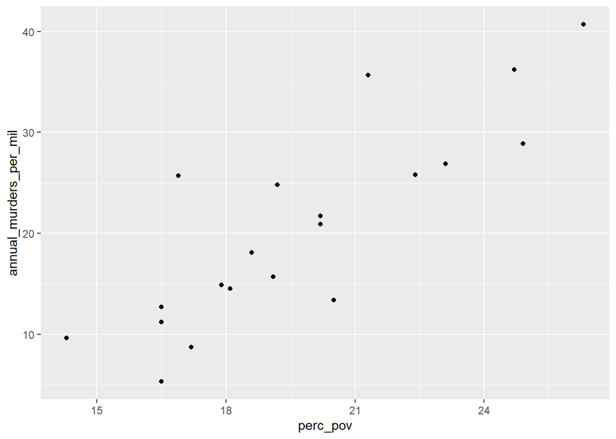

```r
# Scatterplot
ggplot(data = murders) +
  geom_point(mapping = aes(x=perc_pov, y=annual_murders_per_mil))
```

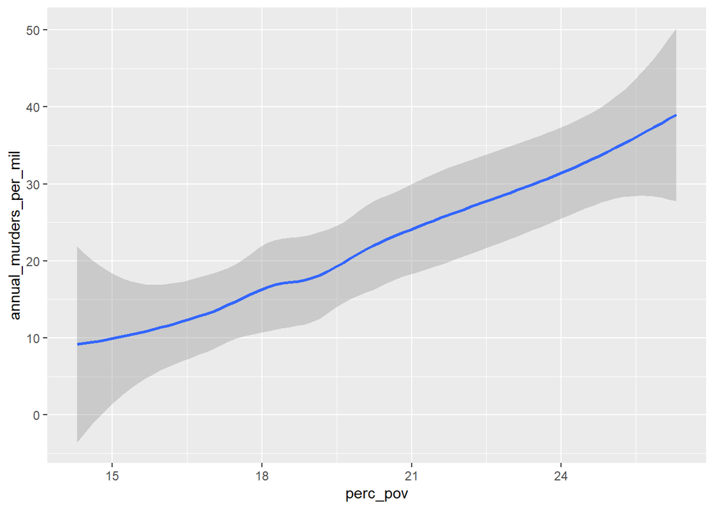

```r
# Line
ggplot(data = murders) +
  geom_smooth(mapping = aes(x=perc_pov, y=annual_murders_per_mil))
```

As we can see, there’s a linear trend there.  
Here, we can use `cor` to check the correlation between two variables.

```r
cor(murders$perc_pov, murders$annual_murders_per_mil)
```

```
## [1] 0.8397782
```

## Linear square regression

```
To conduct linear square regression, we use `lm()` as the following.

y = (slope) x + (intercept)
=> lm(y~x)
```

Then we conduct linear square regression.

```r
fit <- lm(murders$annual_murders_per_mil~murders$perc_pov)
fit
```

```
##
## Call:
## lm(formula = murders$annual_murders_per_mil ~ murders$perc_pov)
##
## Coefficients:
##      (Intercept)  murders$perc_pov
##          -29.901             2.559
```

Meanwhile, there’s quite some more attributes about the regression that we can make use of.

```r
attributes(fit)
```

```
## $names
##  [1] "coefficients"  "residuals"     "effects"       "rank"
##  [5] "fitted.values" "assign"        "qr"            "df.residual"
##  [9] "xlevels"       "call"          "terms"         "model"
##
## $class
## [1] "lm"
```

## coefficients

We can print out the y-intercept and slope by accessing `coefficients` variables.

```r
# Intercept
fit$coefficients[1]
```

```
## (Intercept)
##   -29.90116
```

```r
fit$coefficients[[1]]
```

```
## [1] -29.90116
```

```r
# Slope
fit$coefficients[2]
```

```
## murders$perc_pov
##          2.55939
```

```r
fit$coefficients[[2]]
```

```
## [1] 2.55939
```

```r
fit$coefficients[[2]] * 20 + fit$coefficients[[1]]
```

```
## [1] 21.28663
```

## residuals

There’s also easier way to get the residuals.

```r
# 1
residuals(fit)
```

```
##          1          2          3          4          5          6
## -1.1287655 -9.1663239  3.2892166 -7.0287655  5.5608826  0.3712345
##          7          8          9         10         11         12
## -0.8985070 11.0861645 -5.4203383  2.9018915 -1.9237889 -2.3207368
##         13         14         15         16         17         18
## -3.2831785  2.8842399  0.3965163 -4.9276380 -1.0119110 -1.6291641
##         19         20
## -0.0985070 12.3474786
```

```r
#2
fit$residuals
```

```
##          1          2          3          4          5          6
## -1.1287655 -9.1663239  3.2892166 -7.0287655  5.5608826  0.3712345
##          7          8          9         10         11         12
## -0.8985070 11.0861645 -5.4203383  2.9018915 -1.9237889 -2.3207368
##         13         14         15         16         17         18
## -3.2831785  2.8842399  0.3965163 -4.9276380 -1.0119110 -1.6291641
##         19         20
## -0.0985070 12.3474786
```

and therefore, we can plot *residual plots*

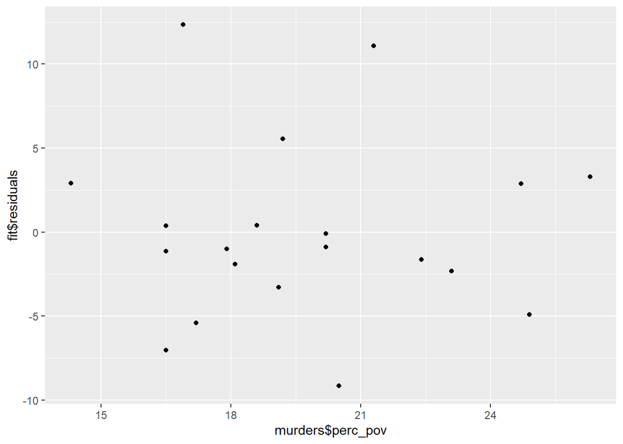

```r
ggplot() +
  geom_point(mapping = aes(x = murders$perc_pov, y =fit$residuals))
```

## fitted.values

We can use `fitte.values` variables to plot the regression line and real data point scatterplot.

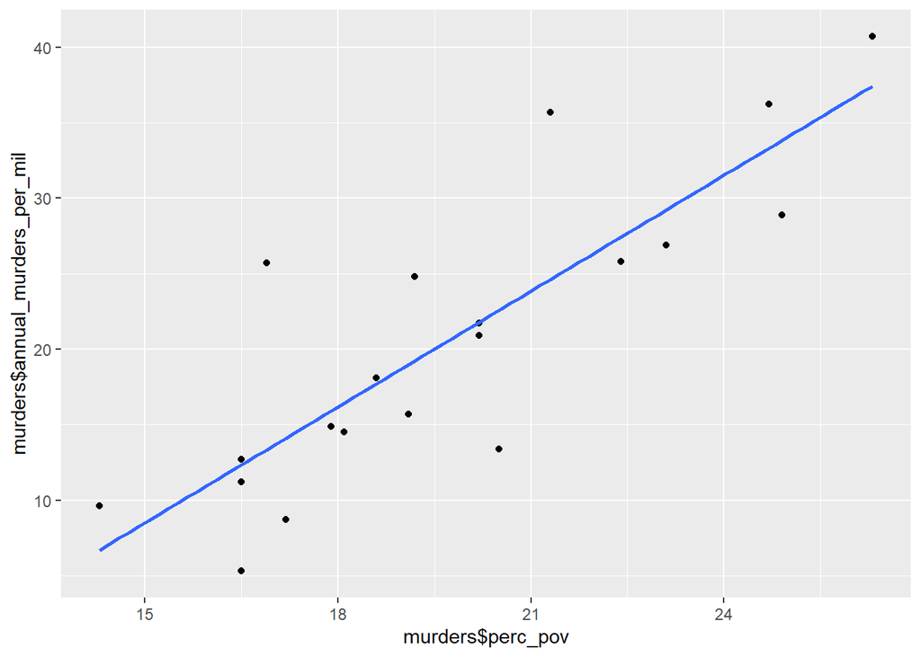

```r
ggplot() +
  geom_point(mapping = aes(x=murders$perc_pov, y=murders$annual_murders_per_mil)) +
  geom_smooth(mapping = aes(x = murders$perc_pov, y =fit$fitted.values))
```

## summary()

With `summary()` function, we can see furthur detail of our linear square regression just as we do on ANOVA result.

```r
summary(fit)
```

```
##
## Call:
## lm(formula = murders$annual_murders_per_mil ~ murders$perc_pov)
##
## Residuals:
##     Min      1Q  Median      3Q     Max
## -9.1663 -2.5613 -0.9552  2.8887 12.3475
##
## Coefficients:
##                  Estimate Std. Error t value Pr(>|t|)
## (Intercept)       -29.901      7.789  -3.839   0.0012 **
## murders$perc_pov    2.559      0.390   6.562 3.64e-06 ***
## ---
## Signif. codes:  0 '***' 0.001 '**' 0.01 '*' 0.05 '.' 0.1 ' ' 1
##
## Residual standard error: 5.512 on 18 degrees of freedom
## Multiple R-squared:  0.7052, Adjusted R-squared:  0.6889
## F-statistic: 43.06 on 1 and 18 DF,  p-value: 3.638e-06
```

### Question

Now try use the same dataset to see the relation between `employment rate` and `murder rate`. (employment rate = 1 + unemployment rate)

1. Do the plots to see whther there’s linearity relationship.
2. See the correlation of the two variables.
3. Conduct linear square regression and find the `intercept` and `slope`.
4. What would the murder rate be if the employment rate were 70%.
5. Do residual plots.
6. Plot the regression line and real data point scatterplot together.